# Homework 1

## Question 1: Upper and Lower Peninsula Health Disparities

```r
# use the subset of data that's specific to 2010
# and remove any unnecessary columns for the analysis
subset_2010 = subset(michdata, YEAR == 2010)
mich_data_2010 = subset(michdata, YEAR == 2010)
subset_columns = c("ACS_PCT_UNEMPLOY", "UPPER_PEN")
subset_2010 = subset_2010[subset_columns]
```

### Part A

Below are the box plots for the upper and lower peninsular civilian unemployment rates.

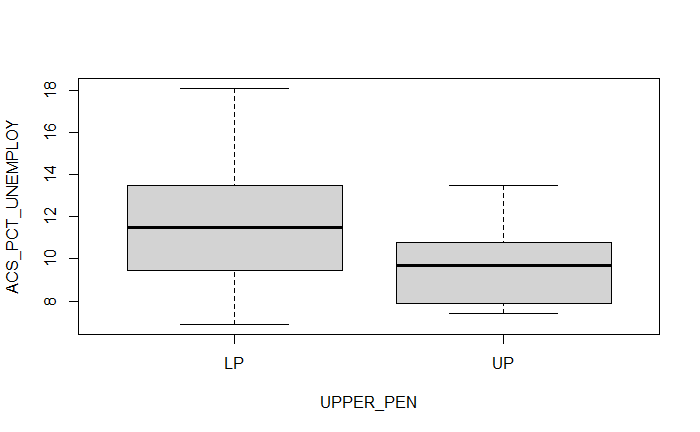

```r
boxplot(ACS_PCT_UNEMPLOY ~ UPPER_PEN,
        data = subset_2010)
```

### Part B

```r
peninsular_means = aggregate(
  x = subset_2010$ACS_PCT_UNEMPLOY,
  by = list(subset_2010$UPPER_PEN),
  FUN = mean
)
peninsular_means
```

| Group.1 | x |
| --- | --- |
| LP | 11.780735 |
| UP | 9.615333 |

```r
peninsular_medians = aggregate(
  x = subset_2010$ACS_PCT_UNEMPLOY,
  by = list(subset_2010$UPPER_PEN),
  FUN = median
)
peninsular_medians
```

| Group.1 | x |
| --- | --- |
| LP | 11.51 |
| UP | 9.69 |

### Part C

The lower peninsula has a marginally higher mean unemployment rate than the upper peninsula, with the lower peninsula coming in at an average of 11.78% and the upper peninsula coming in at an average of 9.62%. The medians have a similar relationship to one another, with the lower peninsula having a higher unemployment at 11.51% and the upper peninsula having 9.69%.

### Part D

Below, we use the two-sampled t-test to compare the means of the county-level civilian unemployment rates in the upper and lower peninsulas. The result is a p-value of 0.003 < 0.05, and so we reject the null hypothesis that the mean civilian unemployment in the lower peninsula is equal to that of the upper peninsula.

```r
t.test(
  ACS_PCT_UNEMPLOY ~ UPPER_PEN,
  data = subset_2010,
  var.equal = TRUE
)
```

```
    Two Sample t-test

data:  ACS_PCT_UNEMPLOY by UPPER_PEN
t = 2.991, df = 81, p-value = 0.003683
alternative hypothesis: true difference in means between group LP and group UP is not equal to 0
95 percent confidence interval:
 0.7249325 3.6058715
sample estimates:
mean in group LP mean in group UP
       11.780735         9.615333
```

## Part E

Below, we use the nonparametric Mann-Whitney U Test to determine whether the distributions are the same between the groups without specifying the type of distribution. The procedure calculated a p-value of 0.00351 < 0.05, meaning we reject our null hypothesis that the distributions of civilian unemployment is the same in the upper peninsula as the lower peninsula.

```r
wilcox.test(
  ACS_PCT_UNEMPLOY ~ UPPER_PEN,
  data = subset_2010,
  correct = FALSE
)
```

```
    Wilcoxon rank sum test

data:  ACS_PCT_UNEMPLOY by UPPER_PEN
W = 756.5, p-value = 0.003531
alternative hypothesis: true location shift is not equal to 0
```

## Question 2

### Part A

To speed up the implementation of this question, I’m storing the names of the predictors in a vector to iteratively perform the testing.

ChatGPT also recommended formatting a boxplot formula, which is a great idea! I’m very new to creating functions in R and so suggestions like this will help me write more efficient code in the future. I’ll use the same formula formatting to format the formula for the two-sample t-test.

```
[1] "ACS_MEDIAN_HH_INC tested positive for a significant difference between the upper and lower peninsulas (t-test)"
```

| Group.1 | ACS_MEDIAN_HH_INC |
| --- | --- |
| LP | 44.32632 |
| UP | 38.80153 |

| Group.1 | ACS_MEDIAN_HH_INC |
| --- | --- |
| LP | 42.9715 |
| UP | 39.3390 |

```
[1] "ACS_MEDIAN_HH_INC tested positive for a significant difference between the upper and lower peninsulas (wilcoxon test)"
```

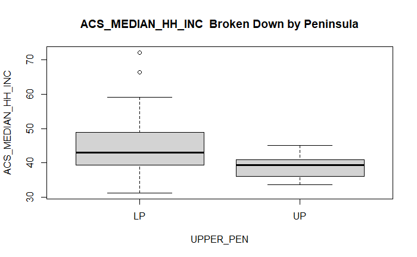

```
[1] "ACS_PCT_HH_1FAM_FOOD_STMP tested positive for a significant difference between the upper and lower peninsulas (t-test)"
```

| Group.1 | ACS_PCT_HH_1FAM_FOOD_STMP |
| --- | --- |
| LP | 35.74956 |
| UP | 30.12667 |

| Group.1 | ACS_PCT_HH_1FAM_FOOD_STMP |
| --- | --- |
| LP | 35.455 |
| UP | 30.670 |

```
[1] "ACS_PCT_HH_1FAM_FOOD_STMP tested positive for a significant difference between the upper and lower peninsulas (wilcoxon test)"
```

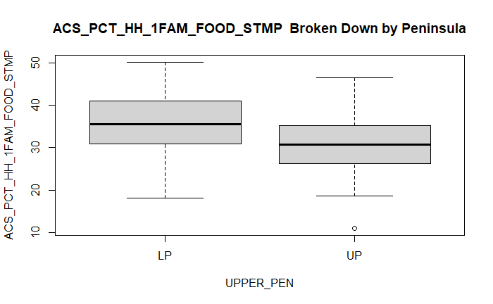

```
[1] "ACS_PCT_LT_HS did not test positive for a significant difference between the upper and lower peninsulas (t-test)"
```

| Group.1 | ACS_PCT_LT_HS |
| --- | --- |
| LP | 12.73456 |
| UP | 11.47933 |

| Group.1 | ACS_PCT_LT_HS |
| --- | --- |
| LP | 12.60 |
| UP | 10.71 |

```
[1] "ACS_PCT_LT_HS did not test positive for a significant difference between the upper and lower peninsulas (wilcoxon test)"
```

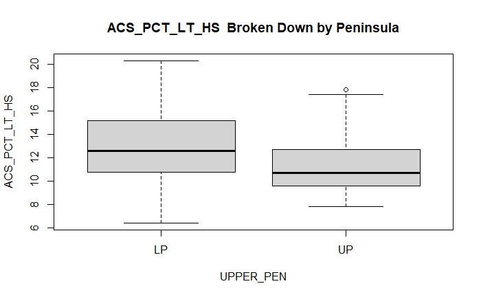

```
[1] "CDCW_SELFHARM_DTH_RATE tested positive for a significant difference between the upper and lower peninsulas (t-test)"
```

| Group.1 | CDCW_SELFHARM_DTH_RATE |
| --- | --- |
| LP | 14.09485 |
| UP | 21.76400 |

| Group.1 | CDCW_SELFHARM_DTH_RATE |
| --- | --- |
| LP | 13.72 |
| UP | 20.84 |

```
[1] "CDCW_SELFHARM_DTH_RATE tested positive for a significant difference between the upper and lower peninsulas (wilcoxon test)"
```

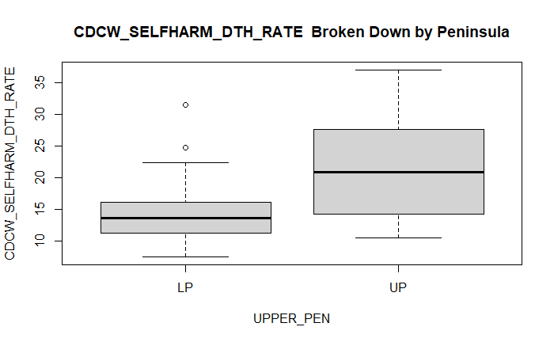

```
[1] "MGV_PCT_MEDICAID did not test positive for a significant difference between the upper and lower peninsulas (t-test)"
```

| Group.1 | MGV_PCT_MEDICAID |
| --- | --- |
| LP | 17.99015 |
| UP | 19.73667 |

| Group.1 | MGV_PCT_MEDICAID |
| --- | --- |
| LP | 18.23 |
| UP | 19.38 |

```
[1] "MGV_PCT_MEDICAID did not test positive for a significant difference between the upper and lower peninsulas (wilcoxon test)"
```

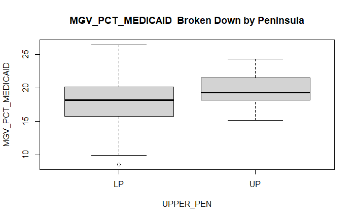

```
[1] "ACS_PCT_UNEMPLOY tested positive for a significant difference between the upper and lower peninsulas (t-test)"
```

| Group.1 | ACS_PCT_UNEMPLOY |
| --- | --- |
| LP | 11.780735 |
| UP | 9.615333 |

| Group.1 | ACS_PCT_UNEMPLOY |
| --- | --- |
| LP | 11.51 |
| UP | 9.69 |

```
[1] "ACS_PCT_UNEMPLOY tested positive for a significant difference between the upper and lower peninsulas (wilcoxon test)"
```

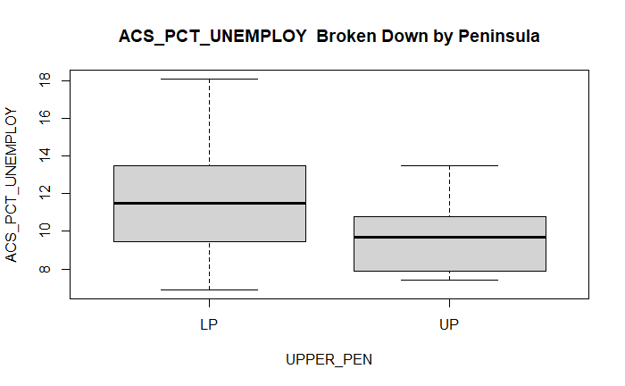

```r
analysis_columns = c("ACS_MEDIAN_HH_INC", "ACS_PCT_HH_1FAM_FOOD_STMP", "ACS_PCT_LT_HS", "CDCW_SELFHARM_DTH_RATE", "MGV_PCT_MEDICAID", "ACS_PCT_UNEMPLOY")

wilcoxon_test = function(data, column) {
  # segment the data into groups 1 and 2
  lp = data[data$UPPER_PEN == "LP", 1]
  up = data[data$UPPER_PEN == "UP", 1]

  results = wilcox.test(lp, up, correct = F)$p.value
  if (results <= 0.05) {
    return(
      paste(
        column,
        "tested positive for a significant difference between the upper and lower peninsulas (wilcoxon test)"
      )
    )
  } else {
    return(
      paste(
        column,
        "did not test positive for a significant difference between the upper and lower peninsulas (wilcoxon test)"
      )
    )
  }

}

t_test = function(data, column) {
  # generate the formula for the regression
  t_test_formula = as.formula(
    paste(
      column,
      " ~ UPPER_PEN"
    )
  )
  # perform the test
  results = t.test(
    t_test_formula,
    data = data,
    var.equal = TRUE
  )
  p_value = results$p.value

  # conditionally return results upon significance
  if (p_value <= 0.05) {
    return(
      paste(
        column,
        "tested positive for a significant difference between the upper and lower peninsulas (t-test)"
      )
    )
  } else {
    return(
      paste(
        column,
        "did not test positive for a significant difference between the upper and lower peninsulas (t-test)"
      )
    )
  }

}

analyze_column_data = function(data, column_names) {
  for (column in column_names) {
    # create the subset of data
    subset_data = data[, c(column, "UPPER_PEN")]

    # generate the box plot formula
    box_plot_formula = as.formula(
      paste(
        column,
        " ~ UPPER_PEN"
      )
    )

    # generate the box plot
    boxplot(
      box_plot_formula,
      data = subset_data,
      main = paste(column, " Broken Down by Peninsula"),
      xlab = "UPPER_PEN",
      ylab = column
    )

    # perform the two-samples t-test
    print(t_test(subset_data, column))

    # calculate group means and medians
    print(aggregate(
      subset_data[column],
      by = list(subset_data$UPPER_PEN),
      FUN = mean
    ))
    print(aggregate(
      subset_data[column],
      by = list(subset_data$UPPER_PEN),
      FUN = median
    ))

    # perform the mann-whitney u-test
    print(wilcoxon_test(subset_data, column))
  }
}

analyze_column_data(mich_data_2010, analysis_columns)
```

## Question 3

As the assignment notes, there’s really no differences in the results between the parametric two-sample t-test and the nonparametric Wilcoxon test for the data from 2010. This could be because the metrics we analyzed are well-characterized by a normal distribution, in which case the tests would perform much of the same function.

```
[1] "ACS_MEDIAN_HH_INC tested positive for a significant difference between the upper and lower peninsulas (t-test)"
```

| Group.1 | ACS_MEDIAN_HH_INC |
| --- | --- |
| LP | 54.81078 |
| UP | 47.58253 |

| Group.1 | ACS_MEDIAN_HH_INC |
| --- | --- |
| LP | 52.1405 |
| UP | 48.4430 |

```
[1] "ACS_MEDIAN_HH_INC tested positive for a significant difference between the upper and lower peninsulas (wilcoxon test)"
```

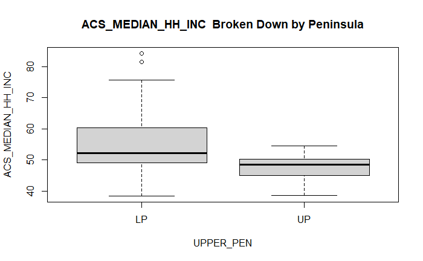

```
[1] "ACS_PCT_HH_1FAM_FOOD_STMP did not test positive for a significant difference between the upper and lower peninsulas (t-test)"
```

| Group.1 | ACS_PCT_HH_1FAM_FOOD_STMP |
| --- | --- |
| LP | 29.62162 |
| UP | 30.03200 |

| Group.1 | ACS_PCT_HH_1FAM_FOOD_STMP |
| --- | --- |
| LP | 30.97 |
| UP | 29.27 |

```
[1] "ACS_PCT_HH_1FAM_FOOD_STMP did not test positive for a significant difference between the upper and lower peninsulas (wilcoxon test)"
```

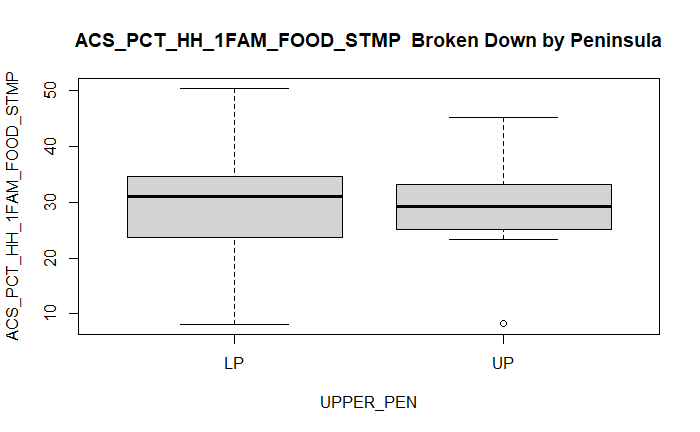

```
[1] "ACS_PCT_LT_HS tested positive for a significant difference between the upper and lower peninsulas (t-test)"
```

| Group.1 | ACS_PCT_LT_HS |
| --- | --- |
| LP | 9.152500 |
| UP | 7.365333 |

| Group.1 | ACS_PCT_LT_HS |
| --- | --- |
| LP | 9.305 |
| UP | 7.470 |

```
[1] "ACS_PCT_LT_HS tested positive for a significant difference between the upper and lower peninsulas (wilcoxon test)"
```

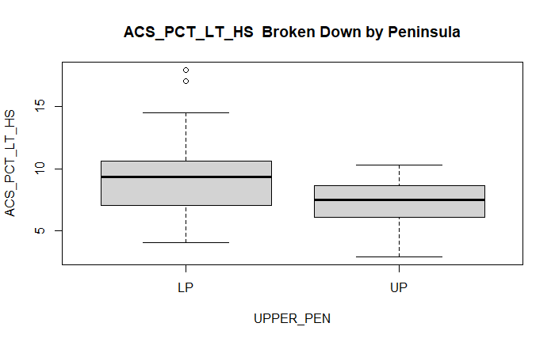

```
[1] "CDCW_SELFHARM_DTH_RATE tested positive for a significant difference between the upper and lower peninsulas (t-test)"
```

| Group.1 | CDCW_SELFHARM_DTH_RATE |
| --- | --- |
| LP | 18.45912 |
| UP | 23.07800 |

| Group.1 | CDCW_SELFHARM_DTH_RATE |
| --- | --- |
| LP | 17.01 |
| UP | 22.24 |

```
[1] "CDCW_SELFHARM_DTH_RATE tested positive for a significant difference between the upper and lower peninsulas (wilcoxon test)"
```

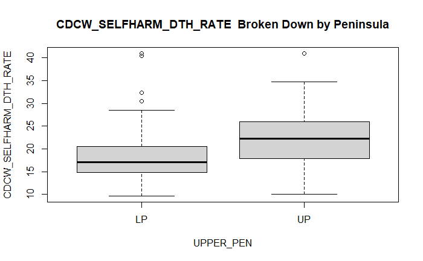

```
[1] "MGV_PCT_MEDICAID tested positive for a significant difference between the upper and lower peninsulas (t-test)"
```

| Group.1 | MGV_PCT_MEDICAID |
| --- | --- |
| LP | 20.54279 |
| UP | 13.63400 |

| Group.1 | MGV_PCT_MEDICAID |
| --- | --- |
| LP | 20.855 |
| UP | 13.040 |

```
[1] "MGV_PCT_MEDICAID tested positive for a significant difference between the upper and lower peninsulas (wilcoxon test)"
```

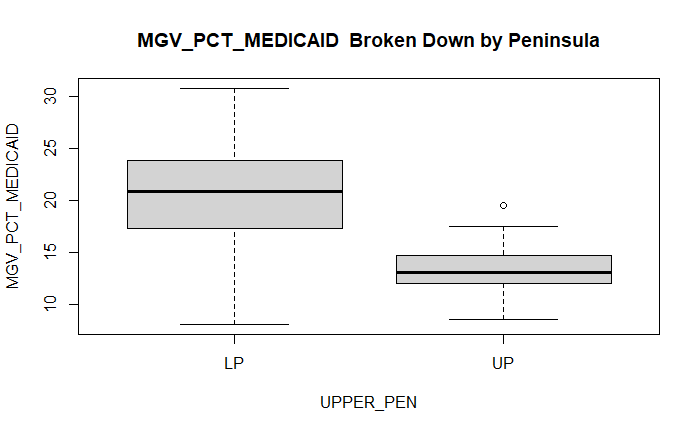

```
[1] "ACS_PCT_UNEMPLOY did not test positive for a significant difference between the upper and lower peninsulas (t-test)"
```

| Group.1 | ACS_PCT_UNEMPLOY |
| --- | --- |
| LP | 5.875147 |
| UP | 5.884667 |

| Group.1 | ACS_PCT_UNEMPLOY |
| --- | --- |
| LP | 5.90 |
| UP | 5.61 |

```
[1] "ACS_PCT_UNEMPLOY did not test positive for a significant difference between the upper and lower peninsulas (wilcoxon test)"
```

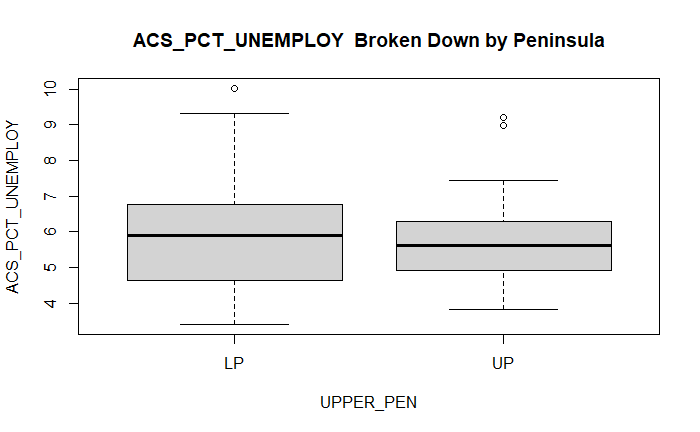

```r
mich_data_2020 = subset(michdata, YEAR == 2020)
analyze_column_data(mich_data_2020, analysis_columns)
```

## Question 5

The first reason for the difference is because of the massive economic resutructure that took place during the pandemic. Stimulus checks were distributed and poverty levels dropped for many households in the country. I would argue that induced poverty (intentional political choice) has a lot to do with the unemployment rates, high school graduation rates, and STAMP/food stamp eligibility.

The second reason has to do with methods of data collection. When folks are at work, or outside of their homes, Census takers are likely unable to reach a lot of people. I wonder whether the response rate of 2020 was higher than that of 2010, in which case the trends we see in 2020 may have been there all along, albeit hidden by a lower response rate.

EDIT: after doing some digging, it looks like the self-response rate between 2010 and 2020 are pretty consistent. 2010 saw a self-response rate of 66.5% while 2020 had a self-response rate of 67%. The Census Bureau expected the response rate to fall due to the COVID-19 pandemic–but the tenacity of their census workers ensured an even higher self-response rate than the previous Census.

SOURCE: https://www.census.gov/newsroom/press-releases/2020/2020-census-all-states-top-99-percent.html